# Basic statistics for health research - week 7, ex. 2

Benjamin Skov Kaas-Hansen

25/3/2021

### Prep and setup

```r
library(plyr)
library(tidyverse)

theme_set(theme_minimal())

pretty_estimates <- function(m) { # m: model object
    cbind(Est. = m$coefficients, confint(m))
}
```

# Growth hormone exercise

## Q1

```r
juul <- read.table("http://publicifsv.sund.ku.dk/~lts/basal/data/juul2.txt", header = TRUE, na = ".") %>%
    mutate(sex = factor(sexnr, levels = 1:2, labels = c("Male", "Female")),
           log_sigf1 = log(sigf1))

model_females <- lm(log_sigf1 ~ age, data = juul, subset = sex == "Female" & tanner == 1)
summary(model_females)
```

```
##
## Call:
## lm(formula = log_sigf1 ~ age, data = juul, subset = sex == "Female" &
##     tanner == 1)
##
## Residuals:
##      Min       1Q   Median       3Q      Max
## -0.99166 -0.17079  0.02702  0.15469  0.77249
##
## Coefficients:
##             Estimate Std. Error t value Pr(>|t|)
## (Intercept)  4.73692    0.12560  37.714  < 2e-16 ***
## age          0.07272    0.01416   5.135 1.14e-06 ***
## ---
## Signif. codes:  0 '***' 0.001 '**' 0.01 '*' 0.05 '.' 0.1 ' ' 1
##
## Residual standard error: 0.3027 on 117 degrees of freedom
##   (270 observations deleted due to missingness)
## Multiple R-squared:  0.1839, Adjusted R-squared:  0.1769
## F-statistic: 26.37 on 1 and 117 DF,  p-value: 1.138e-06
```

```r
exp(pretty_estimates(model_females))
```

```
##                   Est.     2.5 %     97.5 %
## (Intercept) 114.082324 88.958869 146.301059
## age           1.075427  1.045684   1.106015
```

```r
model_males <- update(model_females, subset = sex == "Male" & tanner == 1)
summary(model_males)
```

```
##
## Call:
## lm(formula = log_sigf1 ~ age, data = juul, subset = sex == "Male" &
##     tanner == 1)
##
## Residuals:
##      Min       1Q   Median       3Q      Max
## -1.33211 -0.23283  0.00883  0.26994  1.24455
##
## Coefficients:
##             Estimate Std. Error t value Pr(>|t|)
## (Intercept) 4.286051   0.070465   60.83   <2e-16 ***
## age         0.108971   0.008171   13.34   <2e-16 ***
## ---
## Signif. codes:  0 '***' 0.001 '**' 0.01 '*' 0.05 '.' 0.1 ' ' 1
##
## Residual standard error: 0.4085 on 190 degrees of freedom
##   (181 observations deleted due to missingness)
## Multiple R-squared:  0.4835, Adjusted R-squared:  0.4808
## F-statistic: 177.9 on 1 and 190 DF,  p-value: < 2.2e-16
```

```r
exp(pretty_estimates(model_males)) # exponentiate to get effect estimate (fraction change)
```

```
##                 Est.     2.5 %    97.5 %
## (Intercept) 72.67886 63.247555 83.516538
## age          1.11513  1.097301  1.133249
```

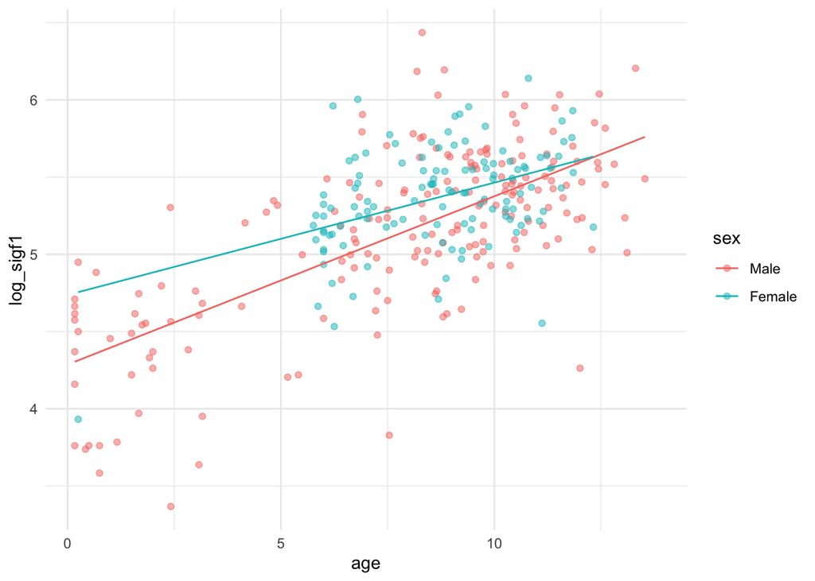

```r
ggplot(filter(juul, tanner == 1), aes(age, log_sigf1, colour = sex)) +
    geom_point(alpha = 0.5) +
    geom_smooth(method = "lm", formula = y ~ x, se = FALSE, size = 0.5)
```

```r
# Percent change in 5 years (disregard intercept here, as it doesn't change over time)
exp(5 * pretty_estimates(model_females))
```

```
##                     Est.        2.5 %       97.5 %
## (Intercept) 1.932377e+10 5.571168e+09 6.702508e+10
## age         1.438480e+00 1.250267e+00 1.655027e+00
```

```r
exp(5 * pretty_estimates(model_males))
```

```
##                     Est.        2.5 %       97.5 %
## (Intercept) 2.027872e+09 1.012089e+09 4.063146e+09
## age         1.724358e+00 1.590850e+00 1.869071e+00
```

## Q2: Are the regression lines parallel?

Make model with interaction. The interaktion near-significant, so we cannot really rule out non-parallel lines.

```r
model_int <- lm(log_sigf1 ~ age * sex, data = juul, subset = tanner == 1)
summary(model_int)
```

```
##
## Call:
## lm(formula = log_sigf1 ~ age * sex, data = juul, subset = tanner ==
##     1)
##
## Residuals:
##      Min       1Q   Median       3Q      Max
## -1.33211 -0.21035  0.01495  0.21837  1.24455
##
## Coefficients:
##                Estimate Std. Error t value Pr(>|t|)
## (Intercept)    4.286051   0.064125  66.839  < 2e-16 ***
## age            0.108971   0.007436  14.655  < 2e-16 ***
## sexFemale      0.450870   0.167051   2.699  0.00734 **
## age:sexFemale -0.036254   0.018915  -1.917  0.05621 .
## ---
## Signif. codes:  0 '***' 0.001 '**' 0.01 '*' 0.05 '.' 0.1 ' ' 1
##
## Residual standard error: 0.3717 on 307 degrees of freedom
##   (445 observations deleted due to missingness)
## Multiple R-squared:  0.4581, Adjusted R-squared:  0.4528
## F-statistic: 86.49 on 3 and 307 DF,  p-value: < 2.2e-16
```

```r
pretty_estimates(model_int)
```

```
##                      Est.       2.5 %       97.5 %
## (Intercept)    4.28605058  4.15987056 4.4122305912
## age            0.10897097  0.09433952 0.1236024168
## sexFemale      0.45086976  0.12216069 0.7795788250
## age:sexFemale -0.03625354 -0.07347263 0.0009655472
```

```r
juul <- mutate(juul, age_around_7 = age - 7) # same trick as above to get differences directly
model_int7 <- lm(log_sigf1 ~ age_around_7 * sex, data = juul, subset = tanner == 1)
summary(model_int7)
```

```
##
## Call:
## lm(formula = log_sigf1 ~ age_around_7 * sex, data = juul, subset = tanner ==
##     1)
##
## Residuals:
##      Min       1Q   Median       3Q      Max
## -1.33211 -0.21035  0.01495  0.21837  1.24455
##
## Coefficients:
##                         Estimate Std. Error t value Pr(>|t|)
## (Intercept)             5.048847   0.027532 183.379  < 2e-16 ***
## age_around_7            0.108971   0.007436  14.655  < 2e-16 ***
## sexFemale               0.197095   0.052371   3.763 0.000201 ***
## age_around_7:sexFemale -0.036254   0.018915  -1.917 0.056208 .
## ---
## Signif. codes:  0 '***' 0.001 '**' 0.01 '*' 0.05 '.' 0.1 ' ' 1
##
## Residual standard error: 0.3717 on 307 degrees of freedom
##   (445 observations deleted due to missingness)
## Multiple R-squared:  0.4581, Adjusted R-squared:  0.4528
## F-statistic: 86.49 on 3 and 307 DF,  p-value: < 2.2e-16
```

```r
pretty_estimates(model_int7)
```

```
##                               Est.       2.5 %       97.5 %
## (Intercept)             5.04884736  4.99467159 5.1030231294
## age_around_7            0.10897097  0.09433952 0.1236024168
## sexFemale               0.19709495  0.09404297 0.3001469299
## age_around_7:sexFemale -0.03625354 -0.07347263 0.0009655472
```

```r
exp(pretty_estimates(model_int7))
```

```
##                               Est.       2.5 %     97.5 %
## (Intercept)            155.8427303 147.6244560 164.518517
## age_around_7             1.1151300   1.0989328   1.131566
## sexFemale                1.2178597   1.0986070   1.350057
## age_around_7:sexFemale   0.9643957   0.9291616   1.000966
```

### If we assume age effect is the same for both sexes, we leave out of the interaction term

This shows a strong effect of both age and sex, which isn’t really surprising.

```r
ancova <- lm(log_sigf1 ~ sex + age, data = juul, subset = tanner == 1)
summary(ancova)
```

```
##
## Call:
## lm(formula = log_sigf1 ~ sex + age, data = juul, subset = tanner ==
##     1)
##
## Residuals:
##      Min       1Q   Median       3Q      Max
## -1.30871 -0.22295  0.01723  0.23137  1.24722
##
## Coefficients:
##             Estimate Std. Error t value Pr(>|t|)
## (Intercept) 4.329936   0.060157   71.98  < 2e-16 ***
## sexFemale   0.141852   0.043916    3.23  0.00137 **
## age         0.103368   0.006867   15.05  < 2e-16 ***
## ---
## Signif. codes:  0 '***' 0.001 '**' 0.01 '*' 0.05 '.' 0.1 ' ' 1
##
## Residual standard error: 0.3733 on 308 degrees of freedom
##   (445 observations deleted due to missingness)
## Multiple R-squared:  0.4516, Adjusted R-squared:  0.448
## F-statistic: 126.8 on 2 and 308 DF,  p-value: < 2.2e-16
```

```r
pretty_estimates(ancova)
```

```
##                  Est.      2.5 %    97.5 %
## (Intercept) 4.3299360 4.21156475 4.4483072
## sexFemale   0.1418516 0.05543845 0.2282647
## age         0.1033683 0.08985678 0.1168799
```

To visualise these parallel lines, we now have to make predictions and show those as a line:

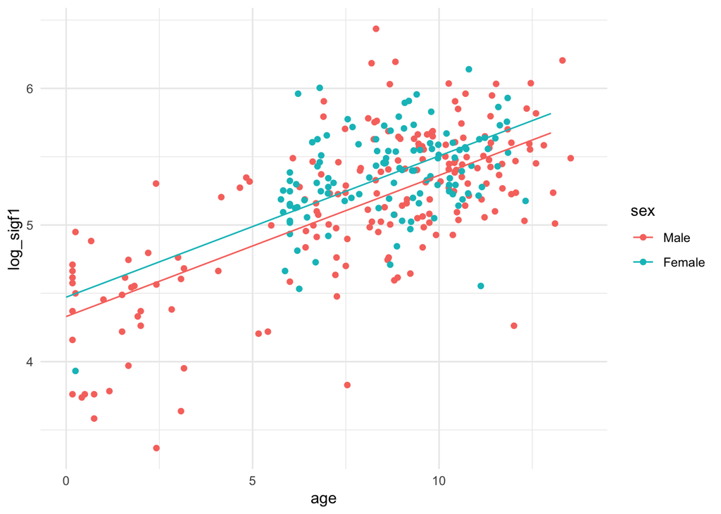

```r
preds <- expand.grid(sex = c("Female", "Male"), age = 0:13, stringsAsFactors = FALSE) %>%
    bind_cols(pred = predict(ancova, .))

ggplot(mapping = aes(x = age, colour = sex)) +
    geom_point(aes(y = log_sigf1), filter(juul, tanner == 1)) +
    geom_line(aes(y = pred), preds)
```

## Q3: Why would linear regression be inappropraite for all Tanner groups?

Just show the scatter plots and a smooth line; it’s in no way straight.

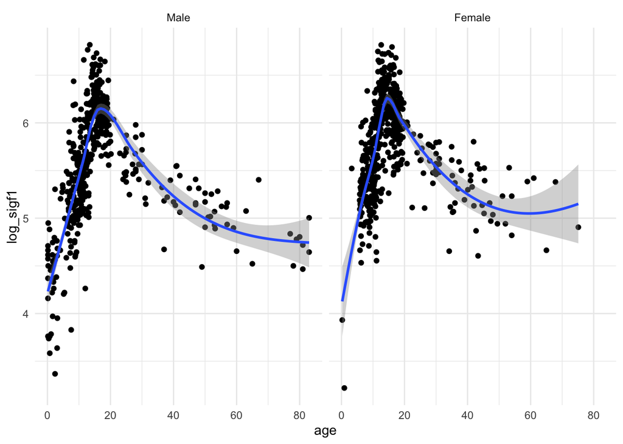

```r
select(juul, log_sigf1, age, sex) %>%
    na.exclude() %>%
    ggplot(aes(age, log_sigf1)) +
        geom_point() +
        geom_smooth() +
        facet_wrap(~ sex)
```

## Q4: Consider only post-pubertal

For males, linear effect seems plausible but definitely not for women.

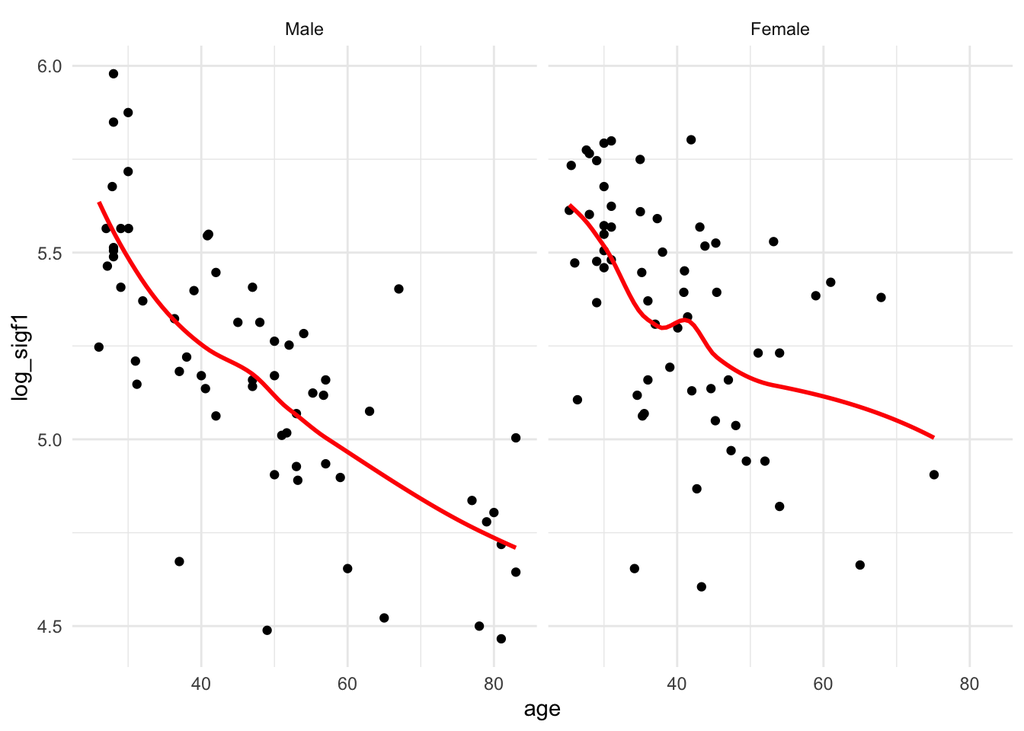

```r
select(juul, log_sigf1, age, sex) %>%
    na.exclude() %>%
    filter(age > 25) %>%
    ggplot(aes(age, log_sigf1)) +
        geom_point() +
        geom_smooth(se = FALSE, colour = "red") +
        facet_wrap(~ sex)
```

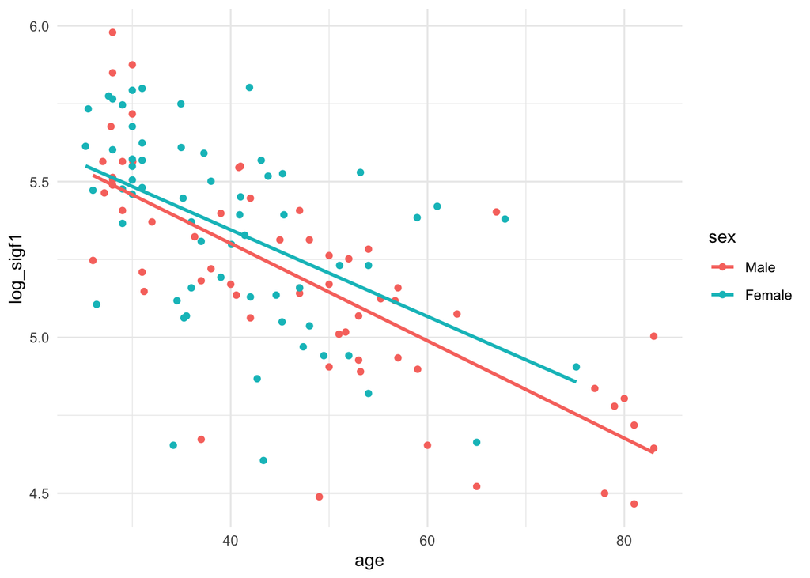

```r
select(juul, log_sigf1, age, sex) %>%
    na.exclude() %>%
    filter(age > 25) %>%
    ggplot(aes(age, log_sigf1, colour = sex)) +
        geom_point() +
        geom_smooth(method = "lm", se = FALSE)
```

Fit model with interaktion as the lines do not seem parallel. The interaction term however is far from significant, and the effect is near-zero.

```r
model_postpub_int <- lm(log_sigf1 ~ sex*age, data = juul, subset = age > 25)
summary(model_postpub_int)
```

```
##
## Call:
## lm(formula = log_sigf1 ~ sex * age, data = juul, subset = age >
##     25)
##
## Residuals:
##      Min       1Q   Median       3Q      Max
## -0.77239 -0.16388  0.02478  0.14975  0.52304
##
## Coefficients:
##                Estimate Std. Error t value Pr(>|t|)
## (Intercept)    5.926591   0.097309  60.905  < 2e-16 ***
## sexFemale     -0.025064   0.154972  -0.162    0.872
## age           -0.015626   0.001927  -8.110 5.36e-13 ***
## sexFemale:age  0.001720   0.003496   0.492    0.624
## ---
## Signif. codes:  0 '***' 0.001 '**' 0.01 '*' 0.05 '.' 0.1 ' ' 1
##
## Residual standard error: 0.2519 on 118 degrees of freedom
##   (10 observations deleted due to missingness)
## Multiple R-squared:  0.4628, Adjusted R-squared:  0.4492
## F-statistic: 33.89 on 3 and 118 DF,  p-value: 7.133e-16
```

```r
pretty_estimates(model_postpub_int)
```

```
##                       Est.        2.5 %       97.5 %
## (Intercept)    5.926590838  5.733892122  6.119289554
## sexFemale     -0.025064446 -0.331951052  0.281822160
## age           -0.015626121 -0.019441441 -0.011810801
## sexFemale:age  0.001719933 -0.005202882  0.008642748
```

–so we remove the interaction term and find the age effect to be significant unlike the sex effect. Not the effect direction: IGF1 increases with age in the young, and decreases with age in adult.

```r
ancova_postpub <- update(model_postpub_int, formula = . ~ sex + age)
summary(ancova_postpub)
```

```
##
## Call:
## lm(formula = log_sigf1 ~ sex + age, data = juul, subset = age >
##     25)
##
## Residuals:
##      Min       1Q   Median       3Q      Max
## -0.77918 -0.15909  0.02754  0.14137  0.51293
##
## Coefficients:
##              Estimate Std. Error t value Pr(>|t|)
## (Intercept)  5.901697   0.082854  71.230  < 2e-16 ***
## sexFemale    0.047541   0.047152   1.008    0.315
## age         -0.015104   0.001603  -9.425 4.31e-16 ***
## ---
## Signif. codes:  0 '***' 0.001 '**' 0.01 '*' 0.05 '.' 0.1 ' ' 1
##
## Residual standard error: 0.2511 on 119 degrees of freedom
##   (10 observations deleted due to missingness)
## Multiple R-squared:  0.4617, Adjusted R-squared:  0.4527
## F-statistic: 51.04 on 2 and 119 DF,  p-value: < 2.2e-16
```

```r
pretty_estimates(ancova_postpub)
```

```
##                    Est.       2.5 %      97.5 %
## (Intercept)  5.90169692  5.73763701  6.06575682
## sexFemale    0.04754112 -0.04582481  0.14090705
## age         -0.01510372 -0.01827688 -0.01193055
```

Again to visualise these parallel lines, we need to predict with the model:

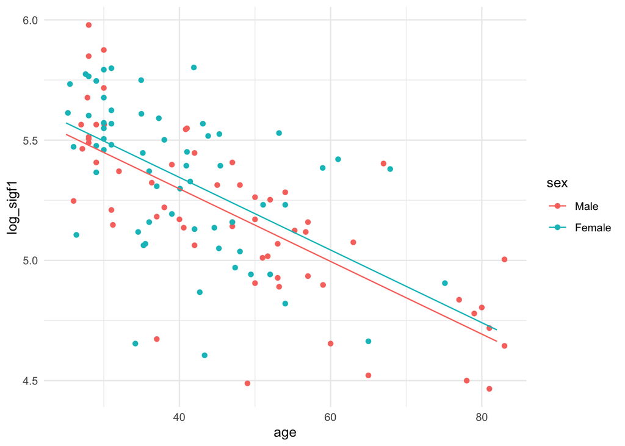

```r
preds <- expand.grid(sex = c("Female", "Male"), age = 25:82, stringsAsFactors = FALSE) %>%
    bind_cols(pred = predict(ancova_postpub, .))

ggplot(mapping = aes(x = age, colour = sex)) +
    geom_point(aes(y = log_sigf1), filter(juul, age > 25)) +
    geom_line(aes(y = pred), preds)
```

## Q5: Include BMI

```r
juul <- mutate(juul, bmi = weight / (height / 100)^2)
glm <- lm(log_sigf1 ~ age + sex + bmi, data = juul, subset = age > 25)
summary(glm) # note that 96 observation are deleted to missingness!
```

```
##
## Call:
## lm(formula = log_sigf1 ~ age + sex + bmi, data = juul, subset = age >
##     25)
##
## Residuals:
##      Min       1Q   Median       3Q      Max
## -0.67014 -0.24267  0.02681  0.25098  0.45912
##
## Coefficients:
##              Estimate Std. Error t value Pr(>|t|)
## (Intercept)  5.448062   0.416322  13.086 2.16e-14 ***
## age         -0.009216   0.005008  -1.840    0.075 .
## sexFemale   -0.015727   0.122412  -0.128    0.899
## bmi          0.011265   0.017218   0.654    0.518
## ---
## Signif. codes:  0 '***' 0.001 '**' 0.01 '*' 0.05 '.' 0.1 ' ' 1
##
## Residual standard error: 0.3021 on 32 degrees of freedom
##   (96 observations deleted due to missingness)
## Multiple R-squared:  0.1032, Adjusted R-squared:  0.01914
## F-statistic: 1.228 on 3 and 32 DF,  p-value: 0.3157
```

```r
pretty_estimates(glm)
```

```
##                     Est.       2.5 %      97.5 %
## (Intercept)  5.448061928  4.60004116 6.296082690
## age         -0.009215896 -0.01941659 0.000984797
## sexFemale   -0.015727063 -0.26507299 0.233618861
## bmi          0.011265095 -0.02380636 0.046336550
```

Always look at the missigness pattern! Note that I transpose it, as I find it to give a more intuitive output. 1’s mean observed value, 0’s mean missing value. Column titles indicate the number of patients with the pattern in that column. The bottom row shows the total number of variables with missing values in that column. The right-most column shows the number of patients with missing values for each variable. This is not the case for the plot which is in the original direction.

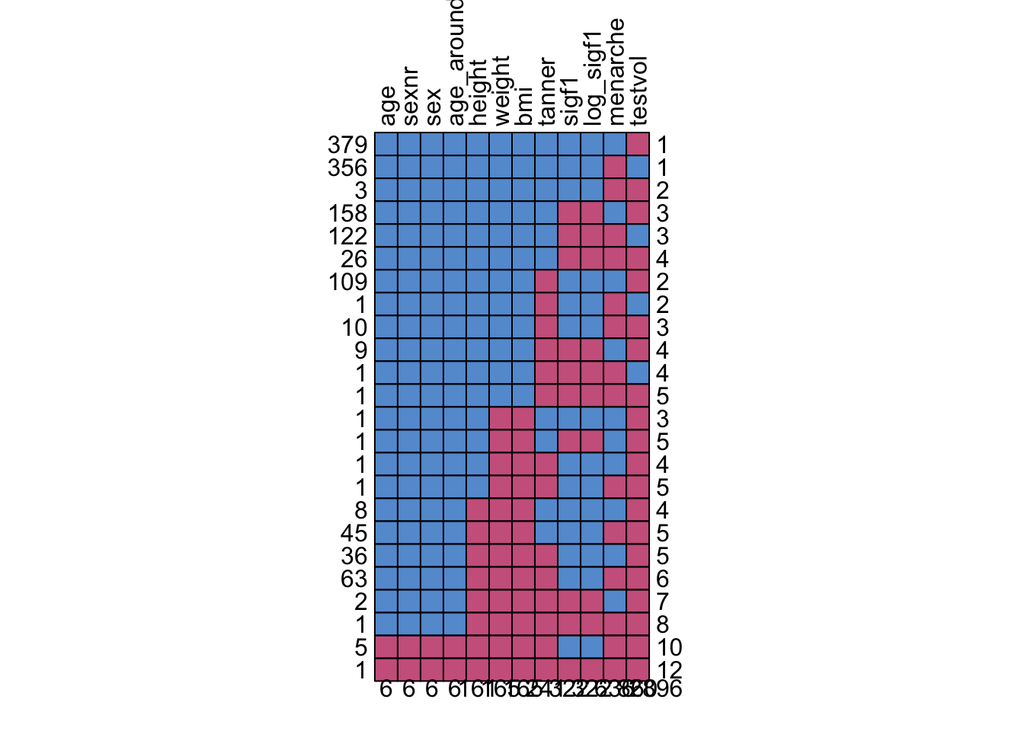

```
##              379 356 3 158 122 26 109 1 10 9 1 1 1 1 1 1 8 45 36 63 2 1  5  1
## age            1   1 1   1   1  1   1 1  1 1 1 1 1 1 1 1 1  1  1  1 1 1  0  0
## sexnr          1   1 1   1   1  1   1 1  1 1 1 1 1 1 1 1 1  1  1  1 1 1  0  0
## sex            1   1 1   1   1  1   1 1  1 1 1 1 1 1 1 1 1  1  1  1 1 1  0  0
## age_around_7   1   1 1   1   1  1   1 1  1 1 1 1 1 1 1 1 1  1  1  1 1 1  0  0
## height         1   1 1   1   1  1   1 1  1 1 1 1 1 1 1 1 0  0  0  0 0 0  0  0
## weight         1   1 1   1   1  1   1 1  1 1 1 1 0 0 0 0 0  0  0  0 0 0  0  0
## bmi            1   1 1   1   1  1   1 1  1 1 1 1 0 0 0 0 0  0  0  0 0 0  0  0
## tanner         1   1 1   1   1  1   0 0  0 0 0 0 1 1 0 0 1  1  0  0 0 0  0  0
## sigf1          1   1 1   0   0  0   1 1  1 0 0 0 1 0 1 1 1  1  1  1 0 0  1  0
## log_sigf1      1   1 1   0   0  0   1 1  1 0 0 0 1 0 1 1 1  1  1  1 0 0  1  0
## menarche       1   0 0   1   0  0   1 0  0 1 0 0 1 1 1 0 1  0  1  0 1 0  0  0
## testvol        0   1 0   0   1  0   0 1  0 0 1 0 0 0 0 0 0  0  0  0 0 0  0  0
##                1   1 2   3   3  4   2 2  3 4 4 5 3 5 4 5 4  5  5  6 7 8 10 12
##
## age             6
## sexnr           6
## sex             6
## age_around_7    6
## height        161
## weight        165
## bmi           165
## tanner        241
## sigf1         322
## log_sigf1     322
## menarche      636
## testvol       860
##              2896
```

```r
library(mice)
t(md.pattern(juul, rotate.names = TRUE))
```